# HICP Voyager

2023-05-20

## Introduction and purpose

The Harmonized Index for Consumer Prices (HICP) is the target indicator for the European Central Bank (ECB) and its monetary policy. The HICP is published by most countries in Europe and enables comparisons of the price development for a range of product categories.

There are a number of dashboards and other interactive visualizations available that show the HICP on the web. They vary in their ease of use and functionality. The purpose with this Shiny app is to allow the user to quickly dig down in the consumer basket and tailor any desired comparisons.

The default reference year in the Eurostat database is currently 2015, but for subindices that were included later than 2015 it is instead a later period, making comparisons less straightforward.

## Features of this app

- Easy selection of countries and product categories.
- Always up-to-date dataset using the Eurostat API Service.
- Automatically recalculated all selected indices to a common base year (otherwise a tedious and manual job).
- Possible to download data and saving the generated plot as a png-file.
- Use instructions are included on the tab “Help” inside the app.

Libraries used: shiny, shinyWidgets, dplyr, zoo, plotly, bslib and eurostat

## Demo (1)

The “eurostat” package let’s us connect to the API service and retrieve the data. Here is data for Germany (DE) and the all-items level (CP00).

```r
library(eurostat)

server_demo <- function(input) {
  hicp_data <- get_eurostat("prc_hicp_midx", filters = list(unit = "I15", geo = input, coicop = "CP00"))
return(hicp_data)
}

df<-as.data.frame(server_demo("DE"))
head(df)
```

```
##   freq unit coicop geo    time values
## 1    M  I15   CP00  DE 1996-01   75.1
## 2    M  I15   CP00  DE 1996-02   75.6
## 3    M  I15   CP00  DE 1996-03   75.7
## 4    M  I15   CP00  DE 1996-04   75.6
## 5    M  I15   CP00  DE 1996-05   75.7
## 6    M  I15   CP00  DE 1996-06   75.8
```

## Demo (2)

…which can then be displayed in a plot.

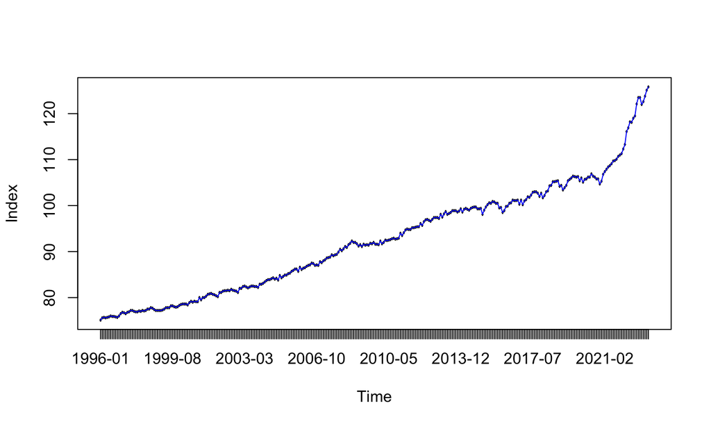